# Incarceration by Race and Gender over Time

Rebecca Chan

2/25/2022

In this report, I focused on race and gender of incarcerated populations in the US. The latest population data came from 2016, when there was a total of 518147 incarcerated individuals in the US. In 2016, the average percentage of women in prison was 8.46% and the average percentage of men was 91.54%. Over time there has been an average change of 6.18 for women and 61.74 for men.

This is a graph showing the average percent of the state female prison population by race. Each different line and color represents the race of those women. I chose to include this data because I wanted to look at female prison populations and how those differ between the races. Interestingly there has been a shift in the percent of the population that is white and black, while the other races have kept lower portions of the population.

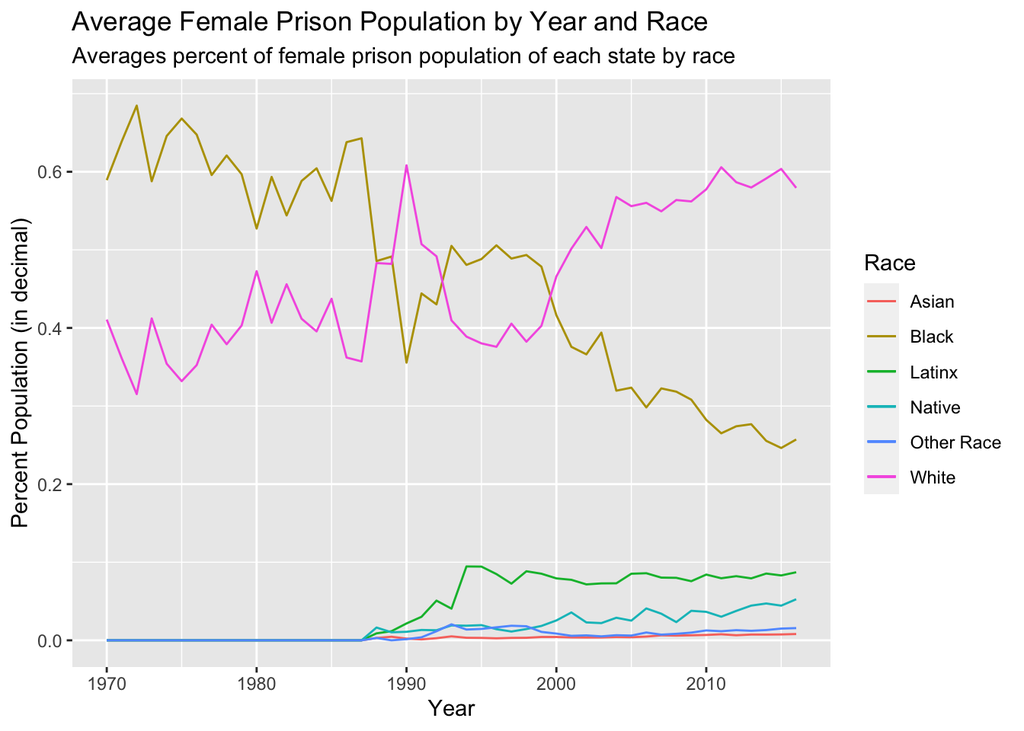

This bar chart shows the number of individuals incarcerated by race, with each column split to show binary gender. This data is from 2016 and is totaled across the data. I thought it would be interesting to look at a recent year and see how the prison population could be divided up. I thought it was interesting to see how small the portions of women are and how that varies between groups.

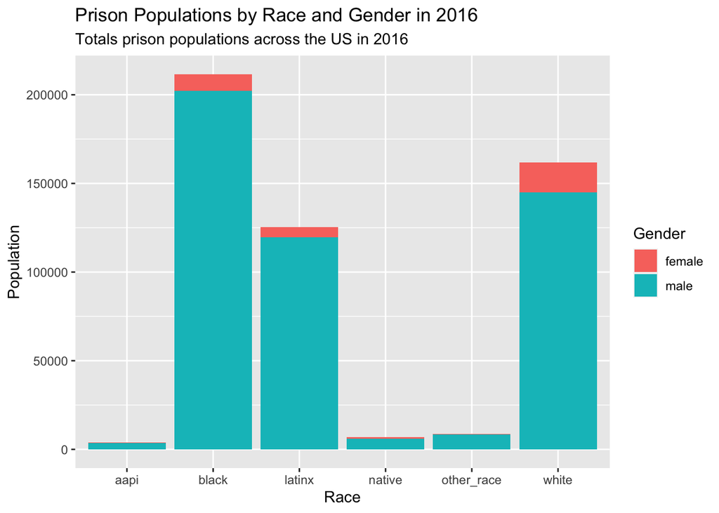

The following is a map that shows the areas with the highest percentages of female prison population, across all races. The numbers are give in decimal form, with the lowest percentage being 0.03 or 3% female (shown in dark purple) and the highest being 0.15 or 15% (light purple). Grey states are representative of states with no data on female prison populations. In all the states, the percentage of women remains quite low, but there is quite a range within that.

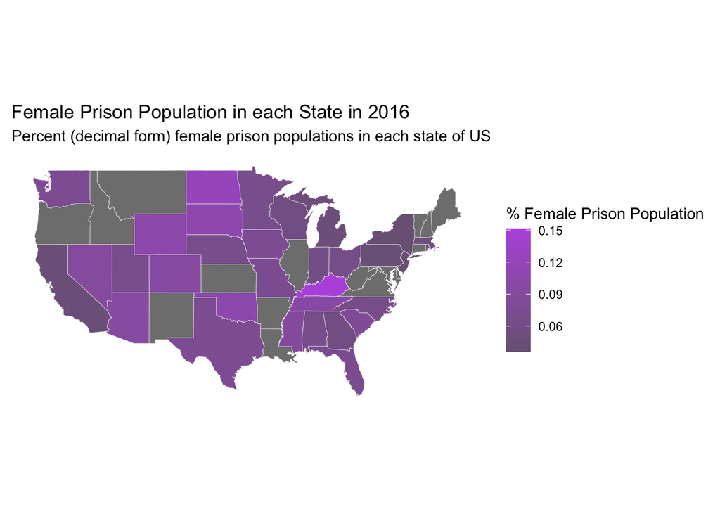